# R Programming

5/9/2020

# Introduction

This report seeks to build a logistic regression model that would be used to predict diagnosis of diabetes based on a number of factors. The analysis uses diabetes dataset that has several variables. However, for this report, the following variables are utilized; age, gender, weight, height, insurance, smoking, cholesterol and whether one has diabetes or not.

# Data Cleaning/Preparation

This section provides the data cleaning/preparation.

```r
setwd("/Users/lealenabefikadu/Downloads")
#opened file and set it equal to a variable
diabetes <- read.csv("diabetes.csv", header = TRUE)
diabetes$height.si=diabetes$height*0.0254
diabetes$weight.si=diabetes$height*0.453592

diabetes$BMI = diabetes$weight.si/diabetes$height.si^2

attach(diabetes)
diabetes$bmi_categorised[BMI < 18.5] <- "underweight"
diabetes$bmi_categorised[BMI >= 18.5  & BMI < 25] <- "normal"
diabetes$bmi_categorised[BMI > 25  & BMI <= 30] <- "overweight"
diabetes$bmi_categorised[BMI > 30] <- "obese"

diabetes$insurance = factor(diabetes$insurance,
                     levels = c(0, 1, 2),
                     labels = c("none", "government", "private"))
diabetes$smoking = factor(diabetes$smoking,
                            levels = c(1, 2, 3),
                            labels = c("current", "never", "ex-smoker"))
```

# Results

## Exploratory Data Analysis

This section provides the summary statiscs of the variables.

```r
attach(diabetes)
bmi_table<-table(bmi_categorised)
bmi_table
```

```
## bmi_categorised
## underweight
##         398
```

```r
prop.table(bmi_table)
```

```
## bmi_categorised
## underweight
##           1
```

```r
gender_table<-table(gender)
gender_table
```

```
## gender
## female   male
##    234    169
```

```r
prop.table(gender_table)
```

```
## gender
##    female      male
## 0.5806452 0.4193548
```

```r
diabetes_table<-table(dm)
diabetes_table
```

```
## dm
##   0   1
## 330  60
```

```r
prop.table(diabetes_table)
```

```
## dm
##         0         1
## 0.8461538 0.1538462
```

```r
mean_age=mean(age, na.rm=TRUE)
mean_BMI=mean(BMI, na.rm = TRUE)
stdev_age=sd(age, na.rm = TRUE)
stdev_BMI=sd(BMI, na.rm = TRUE)
```

A total 403 participants took part in this study (n = 403 observations). In terms of BMI categorization, 98.8% (n = 398) of the participants were categorized as under weight, the remaining 1.2% (n = 5) were missing. Majority of the participants (58.1%, n = 234) were female participants with 41.9% (n = 169) representing male participants in the study. Only 15.4% (n = 60) of the participants were diagnosed with diabetes. The remaining 84.6% (n = 330) were non-diabetic. The average age of the participants was 46.85 years old (SD = 16.31) while the average body mass index (BMI) was 10.69 (SD = 0.64).

# Exploratory Data Analysis

This section provides various plots to visualize on the different variables. Four plots are presented (2 bar charts, 1 scatter plot and 1 histogram).

```r
# Create the data for the insurance chart
insurance_table<-table(insurance)
insurance_table
```

```
## insurance
##       none government    private
##        117        147        139
```

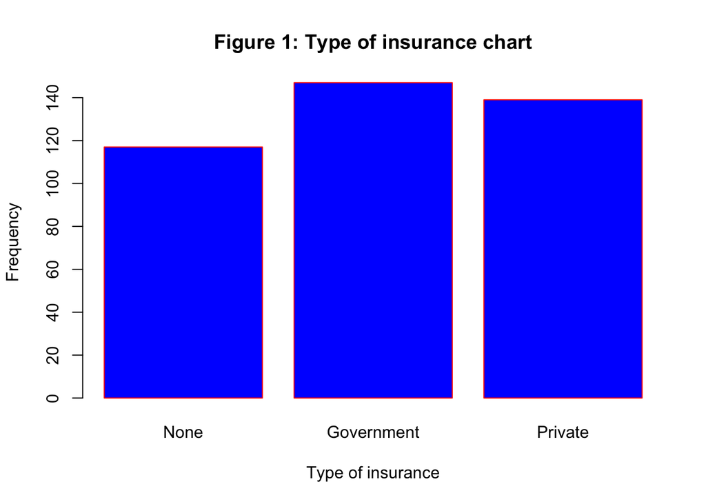

```r
Freq <- c(117,147, 139)
insurance <- c("None","Government", "Private")

# Plot the bar chart
barplot(Freq,names.arg=insurance,xlab="Type of insurance",ylab="Frequency",col="blue",
        main="Figure 1: Type of insurance chart",border="red")
```

```r
# Create the data for the smoking chart
smoking_table<-table(smoking)
smoking_table
```

```
## smoking
##   current     never ex-smoker
##       121       223        59
```

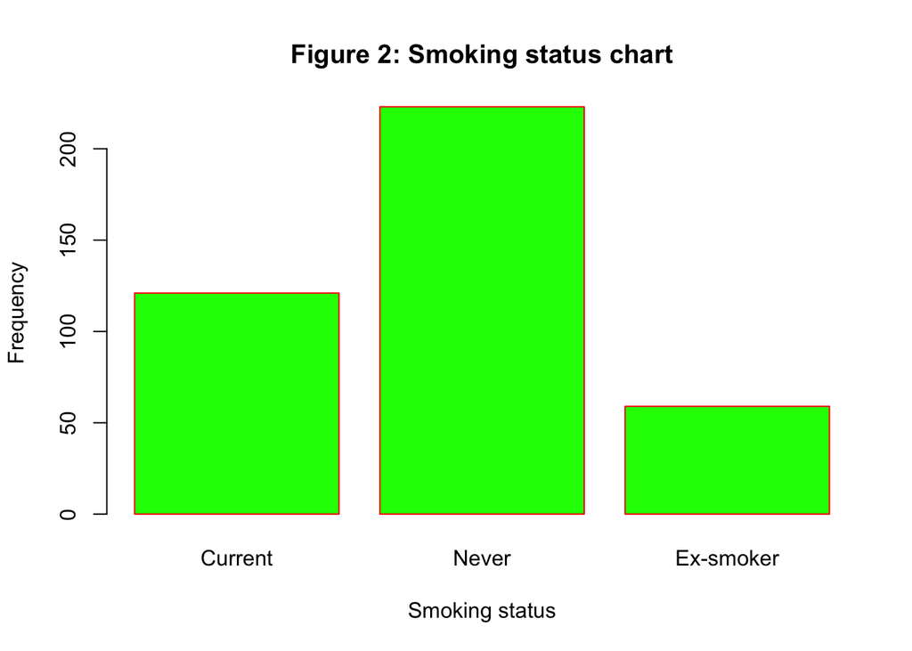

```r
Freq <- c(121,223, 59)
smoking <- c("Current","Never", "Ex-smoker")

# Plot the bar chart
barplot(Freq,names.arg=smoking,xlab="Smoking status",ylab="Frequency",col="green",
        main="Figure 2: Smoking status chart",border="red")
```

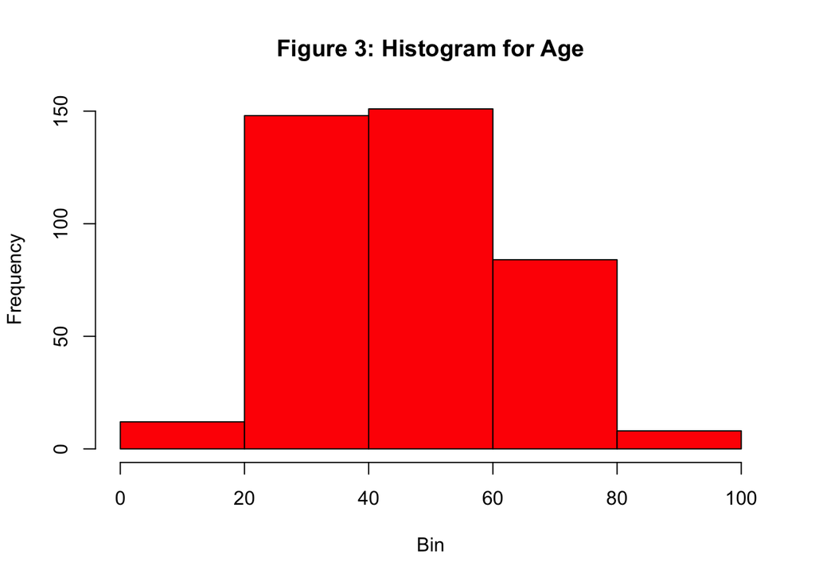

```r
# Histogram for Age

bins <- 5
hist(age, breaks=bins, xlab= "Bin", main="Figure 3: Histogram for Age", col="red")
```

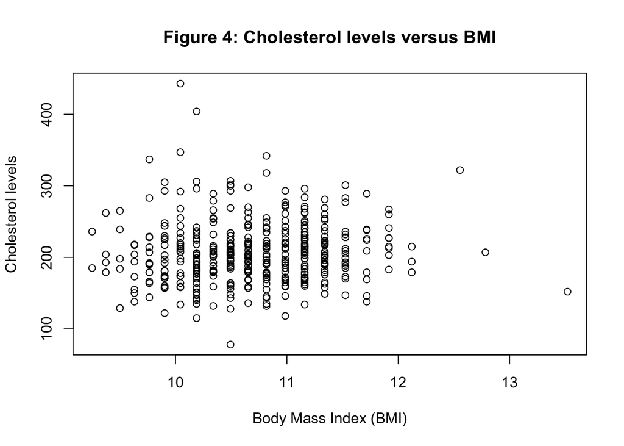

```r
# Scatterplot
plot(chol~BMI, xlab="Body Mass Index (BMI)", ylab="Cholesterol levels", main="Figure 4: Cholesterol levels versus BMI")
```

The first graph (Figure 1) presents a bar chart of insurance. As can be seen, majority (n = 147) had government insurance and were closely followed with private insurance holders (n = 139). However, it is crucial to note that a significant number (n = 117) did not have any insurance.

## Logistic regression

In this section, we build a logistic regression model with diabetes (dm) as the outcome variable, and age, gender, and BMI as the predictors. The results of the analysis are presented below.

```r
glm.fit <- glm(dm ~ age+gender+BMI, data = diabetes, family = binomial)
summary(glm.fit)
```

```
##
## Call:
## glm(formula = dm ~ age + gender + BMI, family = binomial, data = diabetes)
##
## Deviance Residuals:
##     Min       1Q   Median       3Q      Max
## -1.3659  -0.6075  -0.3970  -0.2840   2.5112
##
## Coefficients:
##             Estimate Std. Error z value Pr(>|z|)
## (Intercept)  2.01361    3.74101   0.538   0.5904
## age          0.05754    0.01020   5.643 1.67e-08 ***
## gendermale  -0.53055    0.42636  -1.244   0.2134
## BMI         -0.60618    0.35247  -1.720   0.0855 .
## ---
## Signif. codes:  0 '***' 0.001 '**' 0.01 '*' 0.05 '.' 0.1 ' ' 1
##
## (Dispersion parameter for binomial family taken to be 1)
##
##     Null deviance: 329.79  on 384  degrees of freedom
## Residual deviance: 291.77  on 381  degrees of freedom
##   (18 observations deleted due to missingness)
## AIC: 299.77
##
## Number of Fisher Scoring iterations: 5
```

From the above results, it can be seen that only one of the predictor variables is significant in the model. The significant predictor variable is age (p < 0.05). The other two variables (dummy variable for male and BMI) are insignificant in the model (p > 0.05).

The coefficient of age is given as 0.0575; this suggests that a positive relationship exists between diabetes and age. As one ages, we would expect the likelihood of such an individual to be diagnosed with diabetes to increase. In fact, a unit increase in age is expected to result in a 6% increase in the odds of one being diagnosed with diabetes. Similarly, a unit decrease in age is expected to result in a 6% decrease in the odds of one being diagnosed with diabetes.